# Ejercicio Bootstrap

```r
library(tidyverse)
library(rsample)
library(GGally)
library(robust)
library(ggridges)
library(ggthemes)
library(magrittr)
```

El objetivo del ejercicio es comparar el ajuste lineal clásico (por mínimos cuadrados) con el ajuste robusto, en presencia de contaminación de la muestra. Evaluaremos la performance de los estimadores a través del bootstrap.

## Modelo simulado.

Primero fijemos la semilla

```r
set.seed(141414)
```

Para $n=100$, simule el siguiente modelo.

**Modelo que sigue el 90%** de los datos

$$Y=4+1.5X_{1}+8X_{2}-2X_{3}+\varepsilon
\ \ \ \ \ \ \ \ \ \ \ \ \ \ \ \ \ \ \ \ \ \ \ \ \ \ \ \ \ \ \ \ \ \ \ \ \ \ \ \ \ \ (1)$$

**Modelo que sigue el 10%** de los datos (los contaminados)

$$Y=4+1.5X_{1}+8X_{2}-60X_{3}+\varepsilon
\ \ \ \ \ \ \ \ \ \ \ \ \ \ \ \ \ \ \ \ \ \ \ \ \ \ \ \ \ \ \ \ \ \ \ \ \ \ \ \ \ \ (2)$$

con

- $X_{1}\sim U[0,10],$
- $X_{2}\sim U[0,10],$
- $X_{3}\sim U[0,10],$
- $\varepsilon\sim N (0,1),$

independientes entre sí

Observemos que la única diferencia está en el coeficiente de la variable $X_3$. *El modelo (1) es el modelo verdadero.*

```r
n <- 100
x1 <- runif(n,0,10)
x2 <- runif(n,0,10)
x3 <- runif(n,0,10)
err <- rnorm(n,mean = 0, sd = 1)
# Con los valores de las X y el error calculados, construimos los dos modelos para y
y1 <- 4+1.5*x1[1:90]+8*x2[1:90]-2*x3[1:90]+err[1:90]
y2 <- 4+1.5*x1[91:100]+8*x2[91:100]-60*x3[91:100]+err[91:100]
# Jutnamos ambas y-es
y <- c(y1,y2)
# Va a resultar conveniente tener todo junto en un DF (el error no lo vamos a precisar)
df <- data.frame(x1,x2,x3,y)
#Podemos randomizar el orden de las filas, para que no queden todos los casos patológicos al final
df <- df[sample(nrow(df)),]
df
```

|  | x1 | x2 | x3 | y |
| --- | --- | --- | --- | --- |
| 9 | 4.533940989 | 2.4569304 | 0.880997188 | 29.7727413 |
| 99 | 6.273737857 | 7.6634522 | 9.701052646 | -508.2746936 |
| 14 | 5.685691386 | 5.5173268 | 3.587181692 | 49.4154817 |
| 64 | 9.242535937 | 0.4388327 | 0.333901970 | 24.1954788 |
| 67 | 6.697447782 | 0.8388295 | 9.954539621 | 0.4248596 |
| 94 | 3.194455295 | 2.6600837 | 8.098369872 | -455.2053704 |
| 77 | 1.333373743 | 7.7809082 | 6.807504899 | 53.3396840 |
| 34 | 8.928400427 | 5.4390006 | 6.821349529 | 47.5100985 |
| 42 | 6.220198150 | 9.2215108 | 0.415116483 | 86.6476699 |
| 21 | 4.435689168 | 5.5091112 | 6.400686798 | 41.9309608 |

[output cut: 90 more lines]

una buena forma de visualizar los datos sería con un diagrama de dispersión de Y respecto a las X

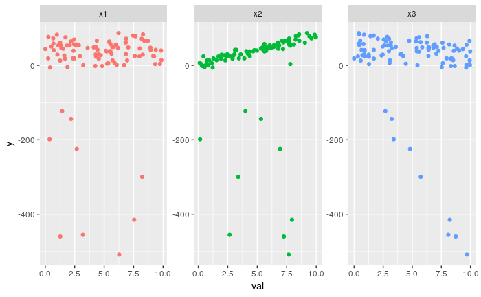

```r
df %>%
  gather(var,val,1:3) %>%
  ggplot(.,aes(val,y,color=var))+
  geom_point()+
  facet_wrap(~var, scales = "free")+
  theme(legend.position = "none")
```

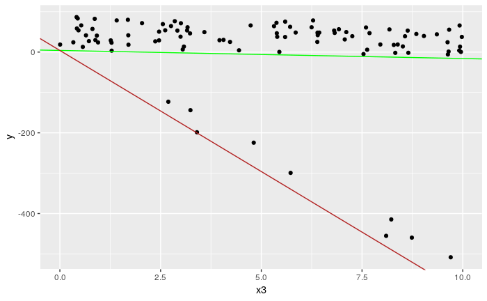

```r
df %>%
  ggplot(.,aes(y=y))+
  geom_point(aes(x3))+
  geom_abline(slope = -2,intercept = 4, color="green")+
  geom_abline(slope = -60,intercept = 4, color = "firebrick")
```

claramente se ven 10 casos con un comportamiento patológico.

En el segundo gráfico, podemos ver el detalle del comportamiento de las Y respecto a $x_3$:

- Notemos que las observaciones quedan por encima de las rectas trazadas por el efecto aditivo de $x_1$ y $x_2$
- Si no estuviera dicho efecto, las observaciones quedarían centradas sobre la recta correspondiente, con la dispersión agregada por el término del error.

## Ajuste modelo lineal

```r
modelo <- lm(y~x1+x2+x3,data = df)
summary(modelo)
```

```
Call:
lm(formula = y ~ x1 + x2 + x3, data = df)

Residuals:
    Min      1Q  Median      3Q     Max
-494.34    6.79   28.22   48.86   74.62

Coefficients:
            Estimate Std. Error t value Pr(>|t|)
(Intercept)   13.138     35.012   0.375   0.7083
x1             2.746      3.931   0.699   0.4865
x2             5.338      3.923   1.361   0.1768
x3            -8.783      3.549  -2.475   0.0151 *
---
Signif. codes:  0 ‘***’ 0.001 ‘**’ 0.01 ‘*’ 0.05 ‘.’ 0.1 ‘ ’ 1

Residual standard error: 109.8 on 96 degrees of freedom
Multiple R-squared:  0.07943,   Adjusted R-squared:  0.05066
F-statistic: 2.761 on 3 and 96 DF,  p-value: 0.0463
```

```r
tidy(modelo,conf.int = TRUE,conf.level = 0.95)
```

| term | estimate | std.error | statistic | p.value | conf.low | conf.high |
| --- | --- | --- | --- | --- | --- | --- |
| (Intercept) | 13.138061 | 35.012263 | 0.3752417 | 0.7083085 | -56.360731 | 82.636853 |
| x1 | 2.746168 | 3.930696 | 0.6986468 | 0.4864619 | -5.056202 | 10.548537 |
| x2 | 5.338467 | 3.923089 | 1.3607816 | 0.1767689 | -2.448803 | 13.125738 |
| x3 | -8.783404 | 3.548778 | -2.4750500 | 0.0150751 | -15.827673 | -1.739134 |

```r
glance(modelo)
```

|  | r.squared | adj.r.squared | sigma | statistic | p.value | df | logLik | AIC | BIC | deviance | df.residual |
| --- | --- | --- | --- | --- | --- | --- | --- | --- | --- | --- | --- |
| 1 | 0.0794283 | 0.05066044 | 109.8051 | 2.761008 | 0.04630372 | 4 | -609.7234 | 1229.447 | 1242.473 | 1157486 | 96 |

```r
au <- augment(modelo,df)
```

¿Son significativas las variables?

## Modelo robusto

```r
modelo_robusto <- lmRob(y~x1+x2+x3,data = df)
```

```
Max iteration for refinement reached.
```

```r
summary(modelo_robusto)
```

```
Call:
lmRob(formula = y ~ x1 + x2 + x3, data = df)

Residuals:
      Min        1Q    Median        3Q       Max
-563.6278   -0.7888   -0.1990    0.4478    3.5953

Coefficients:
            Estimate Std. Error t value Pr(>|t|)
(Intercept)  3.91814    0.35882   10.92   <2e-16 ***
x1           1.49676    0.03931   38.08   <2e-16 ***
x2           8.00335    0.03882  206.16   <2e-16 ***
x3          -1.98830    0.03478  -57.17   <2e-16 ***
---
Signif. codes:  0 ‘***’ 0.001 ‘**’ 0.01 ‘*’ 0.05 ‘.’ 0.1 ‘ ’ 1

Residual standard error: 0.9881 on 96 degrees of freedom
Multiple R-Squared: 0.7365

Test for Bias:
            statistic p-value
M-estimate     4.7306  0.3161
LS-estimate    0.4702  0.9763
```

```r
tidy(modelo_robusto)
```

| term | estimate | std.error | statistic | p.value |
| --- | --- | --- | --- | --- |
| (Intercept) | 3.918140 | 0.35882476 | 10.91937 | 1.599048e-18 |
| x1 | 1.496758 | 0.03930730 | 38.07836 | 9.790025e-60 |
| x2 | 8.003347 | 0.03882088 | 206.16087 | 7.052466e-129 |
| x3 | -1.988299 | 0.03477984 | -57.16815 | 5.950304e-76 |

```r
glance(modelo_robusto)
```

| r.squared | deviance | sigma | df.residual |
| --- | --- | --- | --- |
| 0.7364733 | 69.95327 | 0.9881378 | 96 |

```r
au_rob <- augment(modelo_robusto,df)
```

En el modelo robusto ¿Son significativas las variables?

*nota: Para el modelo lmRob no esta implementado `confint()`, por lo que no podemos calcular los intervalos de confianza en la función `tidy()`*

## Gráficos de los residuos

Notemos las diferencias en los gráficos de los residuos de los dos modelos:

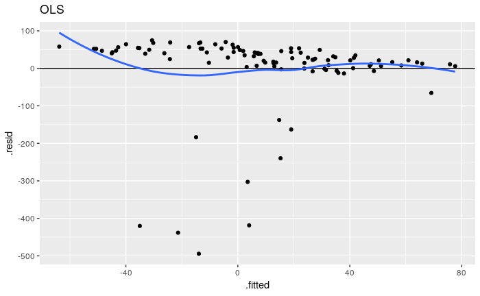

```r
ggplot(au, aes(.fitted, .resid)) +
  geom_point()+
  geom_hline(yintercept = 0) +
  geom_smooth(se = FALSE)+
  labs(title= "OLS")
```

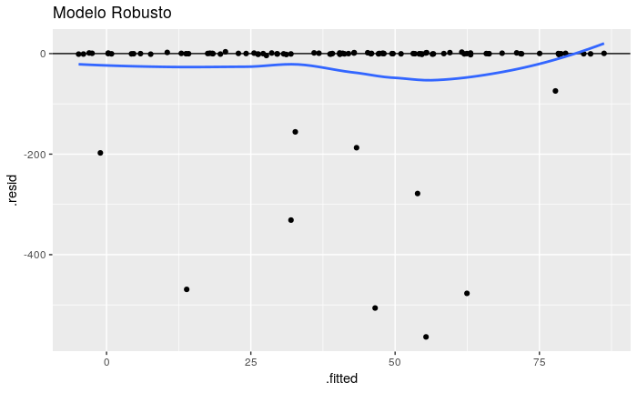

```r
ggplot(au_rob, aes(.fitted, .resid)) +
  geom_point()+
  geom_hline(yintercept = 0) +
  geom_smooth(se = FALSE)+
  labs(title= "Modelo Robusto")
```

para los valores estimados vs los residuos:

- En ambos casos las observaciones patológicas toman valores extremos
- `lm()`: Hay una estructura en los residuos de las observaciones no patológicas, hay una pendiente negativa entre los residuos y los valores estimados.
- `lmRob()`: No hay pendiente, están todos cercanos a 0 (ajustan mejor!)

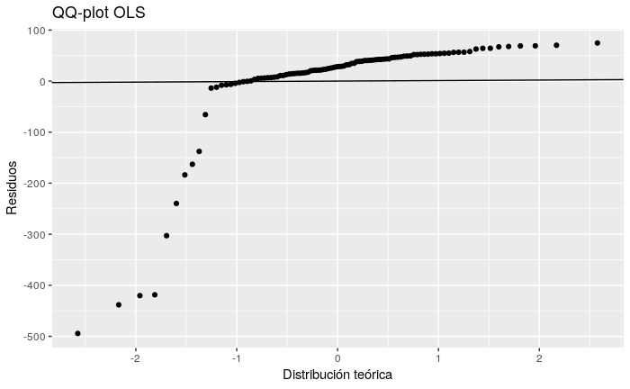

```r
ggplot(au, aes(sample= .resid))+
  stat_qq()+
  geom_abline()+
  labs(title="QQ-plot OLS",
       x = "Distribución teórica",
       y= "Residuos")
```

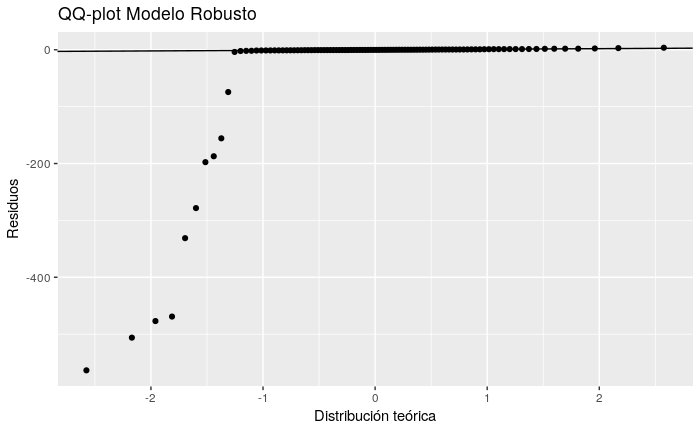

```r
ggplot(au_rob, aes(sample= .resid))+
  stat_qq()+
  geom_abline()+
  labs(title="QQ-plot Modelo Robusto",
       x = "Distribución teórica",
       y= "Residuos")
```

en los QQ-plots:

- Nuevamente hay 10 observaciones patológicas que no siguen la distribución teórica en ningún caso
- `lm()`: El resto de las observaciones tampoco sigue la distribución teórica, sino que en los cuantiles más altos hay una sobre-estimación de los residuos.
- `lmRob()`: Hace un buen trabajo para las observaciones no patológicas

## Bootstrap

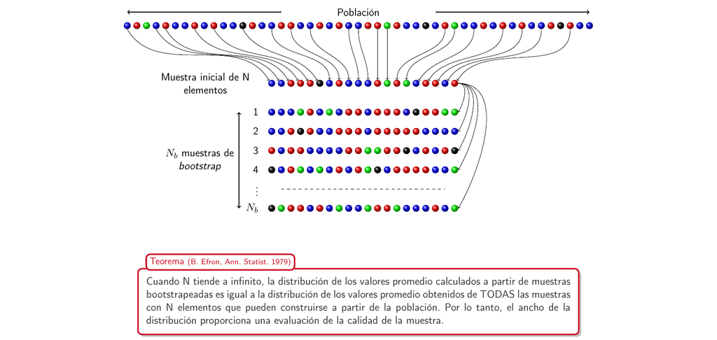

Bootstrap[^1]

- Extraemos una muestra de tamaño 100 con reemplazo de la muestra ${(X_{1i} , X_{2i} , X_{3i} , Y_i )}_{1≤i≤n}$ .
- Ajustamos ambos estimadores (clásico y robusto) a cada muestra bootstrapeada.

Para esto utilizamos la librería `library(rsample)`

```r
muestras_bootstrapeadas <- bootstraps(df,times = 100)
muestras_bootstrapeadas
```

```
# Bootstrap sampling
```

| splits | id |
| --- | --- |
|  | Bootstrap001 |
|  | Bootstrap002 |
|  | Bootstrap003 |
|  | Bootstrap004 |
|  | Bootstrap005 |
|  | Bootstrap006 |
|  | Bootstrap007 |
|  | Bootstrap008 |
|  | Bootstrap009 |
|  | Bootstrap010 |

[output cut: 90 more lines]

Noten que el resultado es un df con dos columnas: un id y los *splits* que contienen para cada bootstrapeo un df.

Tomemos un elemento para ver qué tiene dentro

```r
muestras_bootstrapeadas %>%
  filter(id=="Bootstrap001") %$%
  splits[[1]][[1]]
```

|  | x1 | x2 | x3 | y |
| --- | --- | --- | --- | --- |
| 9 | 4.533940989 | 2.4569304 | 0.880997188 | 29.7727413 |
| 99 | 6.273737857 | 7.6634522 | 9.701052646 | -508.2746936 |
| 14 | 5.685691386 | 5.5173268 | 3.587181692 | 49.4154817 |
| 64 | 9.242535937 | 0.4388327 | 0.333901970 | 24.1954788 |
| 67 | 6.697447782 | 0.8388295 | 9.954539621 | 0.4248596 |
| 94 | 3.194455295 | 2.6600837 | 8.098369872 | -455.2053704 |
| 77 | 1.333373743 | 7.7809082 | 6.807504899 | 53.3396840 |
| 34 | 8.928400427 | 5.4390006 | 6.821349529 | 47.5100985 |
| 42 | 6.220198150 | 9.2215108 | 0.415116483 | 86.6476699 |
| 21 | 4.435689168 | 5.5091112 | 6.400686798 | 41.9309608 |

[output cut: 90 more lines]

```r
table(muestras_bootstrapeadas %>%
  filter(id=="Bootstrap001") %$%
  splits[[1]][[2]])
```

```
  2   4   7   8   9  11  12  13  15  16  17  19  22  24  25  26  27  30  31  34  35  36  37  38  39  40  42
  1   2   1   3   3   3   2   4   4   1   1   2   2   1   1   1   2   1   1   3   2   1   1   1   1   1   1
 43  44  47  50  51  52  53  54  55  57  58  60  61  62  64  66  70  72  73  74  76  77  78  79  80  83  85
  2   1   1   2   2   2   4   1   1   1   1   1   3   1   3   2   1   1   2   1   1   1   2   1   1   1   1
 86  87  88  89  90  93  95  98 100
  1   3   1   1   1   1   2   1   1
```

Cada split contiene un dataframe con la muestra bootstrapeada, y un vector con los números de fila originales.

Si realizamos un table() podemos ver que algunos elementos tienen frecuencia mayor a 1. Esto es por realizamos un muestreo **con reposición** y por lo tanto hay una probabilidad de elegir más de una vez la misma muestra.

Este proceso **replica el muestreo poblacional** pero ahora consideramos a **la muestra original como la población**, de la cual tomamos n muestras.

Nos va a resultar conveniente envolver las funciones de forma tal que sólo necesiten un parámetro de entrada, para mapear

```r
ajuste_lineal_simple <- function(df){
  lm(y~x1+x2+x3,data = df)
}
ajuste_lineal_robusto <- function(df){
  lmRob(y~x1+x2+x3,data = df)
}
```

Con esto podemos calcular el ajuste lineal y el ajuste robusto para cada una de las muestras.

```r
muestras_bootstrapeadas <- muestras_bootstrapeadas %>%
mutate(lm_simple = map(muestras_bootstrapeadas$splits, ajuste_lineal_simple),
       lm_rob = map(muestras_bootstrapeadas$splits, ajuste_lineal_robusto))
```

```
Max iteration for refinement reached.Max iteration for refinement reached.Max iteration for refinement reached.
```

```r
muestras_bootstrapeadas
```

```
# Bootstrap sampling
```

|  | splits | id | lm_simple | lm_rob |
| --- | --- | --- | --- | --- |
| 1 |  | Bootstrap001 |  |  |
| 2 |  | Bootstrap002 |  |  |
| 3 |  | Bootstrap003 |  |  |
| 4 |  | Bootstrap004 |  |  |
| 5 |  | Bootstrap005 |  |  |
| 6 |  | Bootstrap006 |  |  |
| 7 |  | Bootstrap007 |  |  |
| 8 |  | Bootstrap008 |  |  |
| 9 |  | Bootstrap009 |  |  |
| 10 |  | Bootstrap010 |  |  |

[output cut: 90 more lines]

Para recuperar los parámetros de cada una de las estimaciones, vamos a realizar un `map()` sobre la función `tidy()`

```r
parametros_lm <- muestras_bootstrapeadas %>%
  mutate(tdy = map(lm_simple, tidy)) %>%
  unnest(tdy, .drop = TRUE) %>%
  mutate(modelo = "lm") %>%
  select(id,term,estimate,modelo)
parametros_lmRob <- muestras_bootstrapeadas %>%
  mutate(tdy = map(lm_rob, tidy)) %>%
  unnest(tdy, .drop = TRUE) %>%
  mutate(modelo = "lm_rob") %>%
  select(id,term,estimate,modelo)
parametros <- bind_rows(parametros_lm,parametros_lmRob)
parametros
```

| id | term | estimate | modelo |
| --- | --- | --- | --- |
| Bootstrap001 | (Intercept) | 13.47640658 | lm |
| Bootstrap001 | x1 | -1.43167045 | lm |
| Bootstrap001 | x2 | 7.31882574 | lm |
| Bootstrap001 | x3 | -5.57718195 | lm |
| Bootstrap002 | (Intercept) | 1.23114164 | lm |
| Bootstrap002 | x1 | 4.60854288 | lm |
| Bootstrap002 | x2 | 5.93492786 | lm |
| Bootstrap002 | x3 | -8.53582965 | lm |
| Bootstrap003 | (Intercept) | -34.98967468 | lm |
| Bootstrap003 | x1 | 7.55699469 | lm |

[output cut: 790 more lines]

Con todas estas estimaciones podemos graficar los resultados

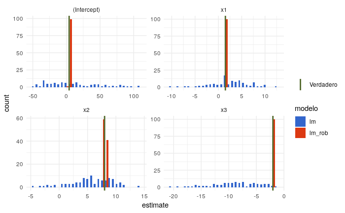

```r
parametros_verdaderos <- data_frame(term=c("(Intercept)","x1","x2","x3"),valor=c(4,1.5,8,-2))
ggplot(parametros, aes(estimate, fill = modelo))+
  geom_histogram(position= "dodge")+
  geom_vline(data=parametros_verdaderos,aes(xintercept = valor,color = "Verdadero"), size=1)+
  scale_color_manual(values = "darkolivegreen","")+
  theme_minimal()+
  scale_fill_gdocs()+
  facet_wrap(~term,scales = "free")
```

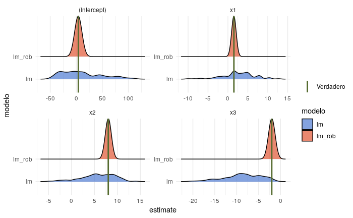

```r
ggplot(parametros, aes(estimate,y=modelo, fill = modelo))+
  geom_density_ridges(alpha=.6)+
  theme_minimal()+
  geom_vline(data=parametros_verdaderos,aes(xintercept = valor,color = "Verdadero"), size=1)+
  scale_color_manual(values = "darkolivegreen","")+
  scale_fill_gdocs()+
  facet_wrap(~term,scales = "free")
```

Algunas conclusiones:

- La distribución de los estimadores en el modelo robusto esta **centrada en los parámetros verdaderos**
- La distribución de los estimadores en el modelo robusto esta **Tiene mucha menos variabilidad**
- Particularmente para la variable patológica ($x_3$), la distribución del modelo lineal simple es especialmente mala, con el valor verdadero muy alejado del centro de masa.
[^1]: diagrama basado en http://www.texample.net/tikz/examples/bootstrap-resampling/